# PHD_Final_version

```python
# Importing all the required libaries for visualization and EDA process
import pandas as pd
import numpy as np
```

```python
# Reading train & test data
# test_data = pd.read_csv('/content/drive/MyDrive/PHD Exam/test_data.csv')
train_data = pd.read_csv('/content/drive/MyDrive/PHD Exam/train_data.csv')
```

```python
# Reading other data also
foot_fall = pd.read_csv("/content/drive/MyDrive/PHD Exam/foot_fall.csv")
dis_freature = pd.read_csv("/content/drive/MyDrive/PHD Exam/discount_features.csv")
```

```python
import json
```

```python
with open('/content/drive/MyDrive/PHD Exam/city_dict.json') as f:
  city_dict = json.load(f)
```

# Data Manipulation and creating base data after merging other data file

- Quick check all the data

```python
# Train data
train_data.head()
```

|  | year | month | day | city | medicine | sales |
| --- | --- | --- | --- | --- | --- | --- |
| 0 | 2015 | 1 | 2 | 1 | 1 | 24.0 |
| 1 | 2015 | 1 | 2 | 1 | 2 | 144.0 |
| 2 | 2015 | 1 | 2 | 1 | 3 | 84.0 |
| 3 | 2015 | 1 | 2 | 1 | 4 | 24.0 |
| 4 | 2015 | 1 | 2 | 1 | 5 | 8.0 |

```python
df_sample= train_data.groupby(['year','month','day','city','medicine']).apply(lambda x: x.sample(frac=0.20))
df_sample.shape
```

```python
# Test data
test_data.head()
```

|  | id | year | month | day | city | medicine |
| --- | --- | --- | --- | --- | --- | --- |
| 0 | 1 | 2018 | 7 | 1 | 1 | 1292 |
| 1 | 2 | 2018 | 7 | 1 | 1 | 1 |
| 2 | 3 | 2018 | 7 | 1 | 1 | 2 |
| 3 | 4 | 2018 | 7 | 1 | 1 | 3 |
| 4 | 5 | 2018 | 7 | 1 | 1 | 4 |

```python
# foot fall data
foot_fall.head()
```

|  | city | 2015-01-02 | 2015-01-03 | 2015-01-04 | 2015-01-05 | 2015-01-06 | 2015-01-07 | 2015-01-08 | 2015-01-09 | 2015-01-10 | 2015-01-11 | 2015-01-12 | 2015-01-13 | 2015-01-14 | 2015-01-15 | 2015-01-16 | 2015-01-17 | 2015-01-18 | 2015-01-19 | 2015-01-20 | 2015-01-21 | 2015-01-22 | 2015-01-23 | 2015-01-24 | 2015-01-25 | 2015-01-26 | 2015-01-27 | 2015-01-28 | 2015-01-29 | … |
| --- | --- | --- | --- | --- | --- | --- | --- | --- | --- | --- | --- | --- | --- | --- | --- | --- | --- | --- | --- | --- | --- | --- | --- | --- | --- | --- | --- | --- | --- | --- |
| 0 | Ahmedabad | 9384.0 | 6808.0 | 8064.0 | 10248.0 | 11180.0 | 6876.0 | 6436.0 | 7104.0 | 5924.0 | 7072.0 | 9236.0 | 10648.0 | 6100.0 | 6284.0 | 7120.0 | 6272.0 | 7216.0 | 9876.0 | 10144.0 | 6228.0 | 6000.0 | 6424.0 | 5872.0 | 7220.0 | 10012.0 | 9652.0 | 6028.0 | 6064.0 | … |
| 1 | Bangalore | 16644.0 | 14640.0 | 15660.0 | 19056.0 | 19740.0 | 14280.0 | 12740.0 | 13480.0 | 11928.0 | 13248.0 | 17112.0 | 19184.0 | 12580.0 | 13220.0 | 13624.0 | 12868.0 | 13208.0 | 17508.0 | 19508.0 | 13340.0 | 11892.0 | 12828.0 | 10952.0 | 12852.0 | 17452.0 | 18564.0 | 12600.0 | 11756.0 | … |
| 2 | Chennai | 19544.0 | 13752.0 | 13736.0 | 19740.0 | 21604.0 | 12820.0 | 12244.0 | 11956.0 | 10508.0 | 11568.0 | 17052.0 | 18852.0 | 11120.0 | 11892.0 | 12136.0 | 11228.0 | 11628.0 | 17488.0 | 18784.0 | 12744.0 | 11144.0 | 11604.0 | 10492.0 | 12436.0 | 17456.0 | 17976.0 | 11188.0 | 10892.0 | … |
| 3 | Delhi | 16832.0 | 13256.0 | 14520.0 | 17324.0 | 17672.0 | 13356.0 | 12408.0 | 13072.0 | 10788.0 | 12332.0 | 15708.0 | 17380.0 | 11748.0 | 12064.0 | 12732.0 | 11092.0 | 13052.0 | 15936.0 | 16676.0 | 12536.0 | 11036.0 | 11488.0 | 10368.0 | 12688.0 | 16672.0 | 16524.0 | 11488.0 | 11468.0 | … |
| 4 | Hyderabad | 13588.0 | 11548.0 | 11600.0 | 16336.0 | 18364.0 | 10788.0 | 9280.0 | 9264.0 | 8848.0 | 9584.0 | 13420.0 | 15972.0 | 8892.0 | 9100.0 | 9372.0 | 8936.0 | 9364.0 | 13568.0 | 16176.0 | 9712.0 | 8520.0 | 8716.0 | 7888.0 | 9048.0 | 14512.0 | 15908.0 | 9232.0 | 8536.0 | … |

5 rows × 1268 columns

```python
# discount feature
dis_freature.head()
```

|  | date | city | medicine | discounted |
| --- | --- | --- | --- | --- |
| 0 | 2016-04-01 | 1 | 1 | 0 |
| 1 | 2016-04-01 | 1 | 2 | 0 |
| 2 | 2016-04-01 | 1 | 3 | 0 |
| 3 | 2016-04-01 | 1 | 4 | 0 |
| 4 | 2016-04-01 | 1 | 5 | 0 |

```python
# City Dictonery
city_dict = pd.DataFrame.from_dict(city_dict,orient='index')
city_dict
```

|  | 0 |
| --- | --- |
| 4 | Mumbai |
| 5 | Delhi |
| 7 | Bangalore |
| 1 | Kolkata |
| 6 | Chennai |
| 8 | Hyderabad |
| 9 | Ahmedabad |
| 3 | Jaipur |
| 10 | Lucknow |
| 2 | Other |

```python
city_dict = city_dict.reset_index()
city_dict = city_dict.rename(columns={city_dict.columns[0]:'city',city_dict.columns[1]:'city_name'})
city_dict
```

|  | city | city_name |
| --- | --- | --- |
| 0 | 4 | Mumbai |
| 1 | 5 | Delhi |
| 2 | 7 | Bangalore |
| 3 | 1 | Kolkata |
| 4 | 6 | Chennai |
| 5 | 8 | Hyderabad |
| 6 | 9 | Ahmedabad |
| 7 | 3 | Jaipur |
| 8 | 10 | Lucknow |
| 9 | 2 | Other |

```python
# Changing city date-type so i can mapped wiht base data
city_dict['city'] = city_dict["city"].astype(int)
```

*Creating based data joining all required data*

```python
# Creating date columns with year,month,day
train_data["date"] = pd.to_datetime(train_data[['year', 'month', 'day']])
train_data.head()
```

|  | year | month | day | city | medicine | sales | date |
| --- | --- | --- | --- | --- | --- | --- | --- |
| 0 | 2015 | 1 | 2 | 1 | 1 | 24.0 | 2015-01-02 |
| 1 | 2015 | 1 | 2 | 1 | 2 | 144.0 | 2015-01-02 |
| 2 | 2015 | 1 | 2 | 1 | 3 | 84.0 | 2015-01-02 |
| 3 | 2015 | 1 | 2 | 1 | 4 | 24.0 | 2015-01-02 |
| 4 | 2015 | 1 | 2 | 1 | 5 | 8.0 | 2015-01-02 |

```python
df_sample= train_data.groupby(['date','city']).apply(lambda x: x.sample(frac=0.20))
df_sample.shape
```

```
(4524903, 7)
```

```python
df_sample = df_sample.reset_index(drop=True)
df_sample.head()
```

|  | year | month | day | city | medicine | sales | date |
| --- | --- | --- | --- | --- | --- | --- | --- |
| 0 | 2015 | 1 | 2 | 1 | 538 | 36.0 | 2015-01-02 |
| 1 | 2015 | 1 | 2 | 1 | 42 | 100.0 | 2015-01-02 |
| 2 | 2015 | 1 | 2 | 1 | 873 | 60.0 | 2015-01-02 |
| 3 | 2015 | 1 | 2 | 1 | 557 | 12.0 | 2015-01-02 |
| 4 | 2015 | 1 | 2 | 1 | 412 | 125.2 | 2015-01-02 |

```python
df_sample.to_csv("/content/drive/MyDrive/PHD Exam/df_sample.csv")
```

#### Creating final data after mapping all data

```python
# Mapping city from city_dict
final_train_df = pd.merge(train_data,city_dict,left_on="city",right_on="city",how="left")
final_train_df.head()
```

|  | year | month | day | city | medicine | sales | date | city_name |
| --- | --- | --- | --- | --- | --- | --- | --- | --- |
| 0 | 2015 | 1 | 2 | 1 | 1 | 24.0 | 2015-01-02 | Kolkata |
| 1 | 2015 | 1 | 2 | 1 | 2 | 144.0 | 2015-01-02 | Kolkata |
| 2 | 2015 | 1 | 2 | 1 | 3 | 84.0 | 2015-01-02 | Kolkata |
| 3 | 2015 | 1 | 2 | 1 | 4 | 24.0 | 2015-01-02 | Kolkata |
| 4 | 2015 | 1 | 2 | 1 | 5 | 8.0 | 2015-01-02 | Kolkata |

```python
# Melting footfall data so we can mapped with final_train_df data
idcol = "city"
varcol = np.setdiff1d(foot_fall.columns,idcol)
foot_fall_melted = pd.melt(foot_fall,id_vars=idcol,value_vars=varcol)
foot_fall_melted["variable"] = foot_fall_melted["variable"].astype('datetime64[ns]')
foot_fall_melted = foot_fall_melted.rename(columns={'value':'footfall_count'})
foot_fall_melted.head()
```

|  | city | variable | footfall_count |
| --- | --- | --- | --- |
| 0 | Ahmedabad | 2015-01-02 | 9384.0 |
| 1 | Bangalore | 2015-01-02 | 16644.0 |
| 2 | Chennai | 2015-01-02 | 19544.0 |
| 3 | Delhi | 2015-01-02 | 16832.0 |
| 4 | Hyderabad | 2015-01-02 | 13588.0 |

```python
# Mapping with base data - "final_train_df" based of city and variable
final_train_df = pd.merge(final_train_df,foot_fall_melted,left_on=["date",'city_name'],right_on=['variable',"city"],how="left")
final_train_df.head()
```

|  | year | month | day | city_x | medicine | sales | date | city_name | city_y | variable | footfall_count |
| --- | --- | --- | --- | --- | --- | --- | --- | --- | --- | --- | --- |
| 0 | 2015 | 1 | 2 | 1 | 1 | 24.0 | 2015-01-02 | Kolkata | Kolkata | 2015-01-02 | 13948.0 |
| 1 | 2015 | 1 | 2 | 1 | 2 | 144.0 | 2015-01-02 | Kolkata | Kolkata | 2015-01-02 | 13948.0 |
| 2 | 2015 | 1 | 2 | 1 | 3 | 84.0 | 2015-01-02 | Kolkata | Kolkata | 2015-01-02 | 13948.0 |
| 3 | 2015 | 1 | 2 | 1 | 4 | 24.0 | 2015-01-02 | Kolkata | Kolkata | 2015-01-02 | 13948.0 |
| 4 | 2015 | 1 | 2 | 1 | 5 | 8.0 | 2015-01-02 | Kolkata | Kolkata | 2015-01-02 | 13948.0 |

```python
# Removing duplicte colums
final_train_df = final_train_df.drop(["variable",'city_y'],axis = 1)
final_train_df = final_train_df.rename(columns={'city_x':'city'})
final_train_df.head()
```

|  | year | month | day | city | medicine | sales | date | city_name | footfall_count |
| --- | --- | --- | --- | --- | --- | --- | --- | --- | --- |
| 0 | 2015 | 1 | 2 | 1 | 1 | 24.0 | 2015-01-02 | Kolkata | 13948.0 |
| 1 | 2015 | 1 | 2 | 1 | 2 | 144.0 | 2015-01-02 | Kolkata | 13948.0 |
| 2 | 2015 | 1 | 2 | 1 | 3 | 84.0 | 2015-01-02 | Kolkata | 13948.0 |
| 3 | 2015 | 1 | 2 | 1 | 4 | 24.0 | 2015-01-02 | Kolkata | 13948.0 |
| 4 | 2015 | 1 | 2 | 1 | 5 | 8.0 | 2015-01-02 | Kolkata | 13948.0 |

```python
# Shape of data frame after mergging all nessary data
final_train_df.shape
```

```
(22624345, 9)
```

```python
# Droping all duplicate rows if it exit in dateframe
final_train_df = final_train_df.drop_duplicates()
final_train_df.shape
```

```
(22622518, 9)
```

*Key Finding*

1.Base data contain duplicate rows so removing and processing further

## Descriptive Statitics

```python
# Checking basic information of dataframe
final_train_df.info()
```

```
<class 'pandas.core.frame.DataFrame'>
Int64Index: 22622518 entries, 0 to 22624344
Data columns (total 9 columns):
 #   Column          Dtype
---  ------          -----
 0   year            int64
 1   month           int64
 2   day             int64
 3   city            int64
 4   medicine        int64
 5   sales           float64
 6   date            datetime64[ns]
 7   city_name       object
 8   footfall_count  float64
dtypes: datetime64[ns](1), float64(2), int64(5), object(1)
memory usage: 1.7+ GB
```

```python
# Univariate analysis of data which give some basic understanding of each and every variable in dataframe
final_train_df.describe()
```

|  | year | month | day | city | medicine | sales | footfall_count |
| --- | --- | --- | --- | --- | --- | --- | --- |
| count | 2.262252e+07 | 2.262252e+07 | 2.262252e+07 | 2.262252e+07 | 2.262252e+07 | 2.262252e+07 | 2.256582e+07 |
| mean | 2.016510e+03 | 6.220861e+00 | 1.572458e+01 | 5.488637e+00 | 1.169604e+03 | 5.166291e+01 | 1.283142e+04 |
| std | 1.023333e+00 | 3.449919e+00 | 8.789327e+00 | 2.849387e+00 | 8.016647e+02 | 1.100335e+02 | 3.777030e+03 |
| min | 2.015000e+03 | 1.000000e+00 | 1.000000e+00 | 1.000000e+00 | 1.000000e+00 | -9.948000e+03 | 3.060000e+03 |
| 25% | 2.016000e+03 | 3.000000e+00 | 8.000000e+00 | 3.000000e+00 | 5.110000e+02 | 1.200000e+01 | 1.028400e+04 |
| 50% | 2.017000e+03 | 6.000000e+00 | 1.600000e+01 | 5.000000e+00 | 1.034000e+03 | 2.800000e+01 | 1.228000e+04 |
| 75% | 2.017000e+03 | 9.000000e+00 | 2.300000e+01 | 8.000000e+00 | 1.718000e+03 | 5.600000e+01 | 1.500400e+04 |
| max | 2.018000e+03 | 1.200000e+01 | 3.100000e+01 | 1.000000e+01 | 3.389000e+03 | 8.299200e+04 | 3.343600e+04 |

*Key Finding and solution*

1. As we can see above sales contain negative value.

*Solution*

1. We can convert negative sales value as zero(0) sales value.
2. We can remove those rows which contain -ve sales value.

```python
#missing data
total = final_train_df.isnull().sum().sort_values(ascending=False)
percent = (final_train_df.isnull().sum()/final_train_df.isnull().count()).sort_values(ascending=False)
missing_data = pd.concat([total, percent], axis=1, keys=['Total', 'Percent'])
missing_data
```

|  | Total | Percent |
| --- | --- | --- |
| footfall_count | 56694 | 0.002506 |
| city_name | 0 | 0.000000 |
| date | 0 | 0.000000 |
| sales | 0 | 0.000000 |
| medicine | 0 | 0.000000 |
| city | 0 | 0.000000 |
| day | 0 | 0.000000 |
| month | 0 | 0.000000 |
| year | 0 | 0.000000 |

*Key Finding and solution*

1. Footfall_count contain .25% value of missing value.

*Solution*

1. It is very small portion of total values so we can impute missing value or we can remove rows which contain missing values.

```python
# unqiue value for few columns of data
print("unique value in year are :",final_train_df["year"].unique())
print('\n')
print("unique value in month are :",final_train_df["month"].unique())
print('\n')
print("unique value in city_name :",final_train_df["city_name"].unique())
print('\n')
print("unique value in medicine are :",final_train_df["medicine"].unique())
print('\n')
print("unique value in day are :",final_train_df["day"].unique())
```

```
unique value in year are : [2015 2016 2017 2018]


unique value in month are : [ 1  2  3  4  5  6  7  8  9 10 11 12]


unique value in city_name : ['Kolkata' 'Other' 'Jaipur' 'Mumbai' 'Delhi' 'Chennai' 'Bangalore'
 'Hyderabad' 'Ahmedabad' 'Lucknow']


unique value in medicine are : [   1    2    3 ... 3387 3388 3389]


unique value in day are : [ 2  3  4  5  6  7  8  9 10 11 12 13 14 15 16 17 18 19 20 21 22 23 24 25
 26 27 28 29 30 31  1]
```

# Data Visualization

```python
# Importing all required libraries for visualization
import matplotlib.pyplot as plt
import seaborn as sns
from IPython.display import display
%matplotlib inline

import plotly.offline as py
import plotly.graph_objs as go
import plotly.tools as tls
```

```python
# To pass the warning messages
import warnings
warnings.filterwarnings('ignore')
```

**Note**

## Data is quite huge not able to do visualization EDA, Below are few sample of visualization and google colab is crashing very frequently and picking ranmdom sample from data and performing visualization EDA

```python
# Creating two seprate list of categorical and numerical variable
cat_variable = ['year', 'month','day','city','city_name']
num_variable = ['sales','footfall_count','medicine']
```

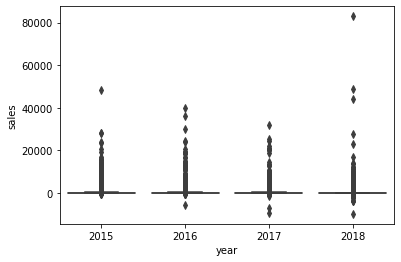

```python
# Box plot between Year and sales
sns.boxplot(data = final_train_df, x='year', y='sales')
```

```python
sns.set(style='whitegrid', palette="deep", font_scale=1.1, rc={"figure.figsize": [8, 5]})
sns.distplot(
    final_train_df['sales'], bins=20, hist_kws={"alpha": 1}
).set(xlabel='year', ylabel='sales');
```

[output not shown]

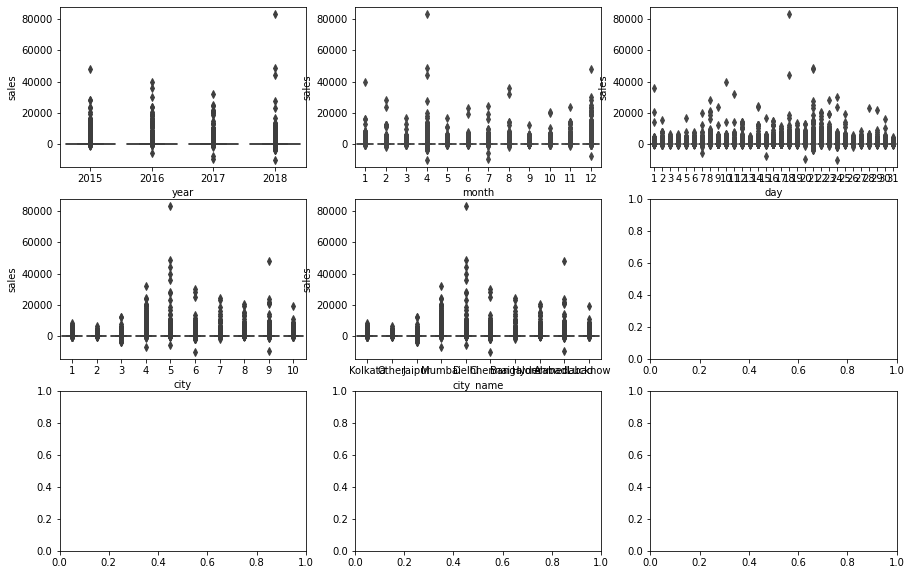

```python
# Box plot for categorical variable
fig, ax = plt.subplots(3, 3, figsize=(15, 10))
for var, subplot in zip(cat_variable, ax.flatten()):
    sns.boxplot(x=var, y='sales', data=final_train_df, ax=subplot)
```

### Random sampling from train data and performing EDA process

```python
final_train_df.shape
```

```
(22622518, 9)
```

```python
# Randomly selecting 25% of the base data = "final_train_df"
train_data_random_data = final_train_df.sample(frac=0.25)
train_data_random_data.shape
```

[output not shown]

```python
train_data_random_data.head()
```

|  | year | month | day | city | medicine | sales | date | city_name | footfall_count |
| --- | --- | --- | --- | --- | --- | --- | --- | --- | --- |
| 12689124 | 2017 | 4 | 22 | 6 | 214 | 12.0 | 2017-04-22 | Chennai | 12024.0 |
| 9636585 | 2016 | 10 | 29 | 10 | 2089 | 60.0 | 2016-10-29 | Lucknow | 8856.0 |
| 1234166 | 2015 | 4 | 15 | 6 | 756 | 20.0 | 2015-04-15 | Chennai | 12340.0 |
| 17948188 | 2017 | 12 | 20 | 3 | 971 | 28.0 | 2017-12-20 | Jaipur | 13872.0 |
| 6684972 | 2016 | 5 | 10 | 9 | 972 | 56.0 | 2016-05-10 | Ahmedabad | 16076.0 |

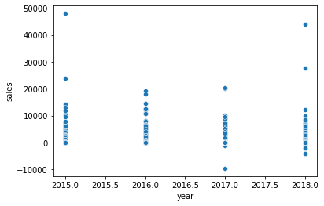

```python
# scatterplot between year and sales
sns.scatterplot(x=train_data_random_data['year'], y=train_data_random_data['sales'])
```

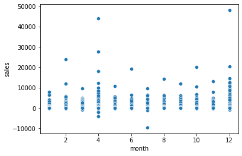

```python
# scatterplot between month and sales
sns.scatterplot(x=train_data_random_data['month'], y=train_data_random_data['sales'])
```

[output not shown]

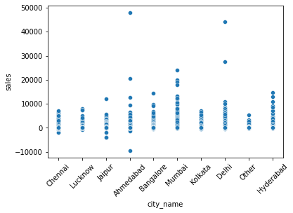

```python
# scatterplot between city_name and sales
k = sns.scatterplot(x=train_data_random_data['city_name'],y=train_data_random_data['sales'])
plt.xticks(rotation=45)
```

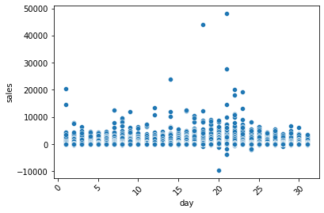

```python
# scatterplot between day and sales
sns.scatterplot(x=train_data_random_data['day'],y=train_data_random_data['sales'])
plt.xticks(rotation=45)
```